# Task 1.2 Apply Quantum Operations

## Objective 1: Circuit Library

### Standard Gates

- Reversible and unitary quantum gates
- Includes abstract operations that are defined by mathematical action like `MCXGate` and it can be implmented with diffrent decompositions
- Also includes structutal operations, they have unique decompositions, they are implemented as a function thar returns a quantum circuit like `real_amplitudes`

```python
from qiskit.circuit.library import XGate

xgate = XGate()
print (f"XGate Matrix:\n{xgate.to_matrix()}")
print(f"√X Matrix:\n{xgate.power(1/2).to_matrix()}")
print(f"CX Gate:\n{xgate.control(1).to_matrix()}")
```

```
XGate Matrix:
[[0.+0.j 1.+0.j]
 [1.+0.j 0.+0.j]]
√X Matrix:
[[0.5+0.5j 0.5-0.5j]
 [0.5-0.5j 0.5+0.5j]]
CX Gate:
[[1.+0.j 0.+0.j 0.+0.j 0.+0.j]
 [0.+0.j 0.+0.j 0.+0.j 1.+0.j]
 [0.+0.j 0.+0.j 1.+0.j 0.+0.j]
 [0.+0.j 1.+0.j 0.+0.j 0.+0.j]]
```

```python
from qiskit.circuit.library import get_standard_gate_name_mapping

print(f"Standard Gate Mapping:{get_standard_gate_name_mapping()}")
```

[output not shown]

#### One qubit Standard Gates

- HGate --> Single-qubit Hadamard gate.
- IGate --> Identity gate.
- PhaseGate --> Single-qubit rotation about the Z axis.
- RGate --> Rotation θθ around the cos(ϕ)x+sin(ϕ)ycos(ϕ)x+sin(ϕ)y axis.
- RXGate --> Single-qubit rotation about the X axis.
- RYGate --> Single-qubit rotation about the Y axis.
- RZGate --> Single-qubit rotation about the Z axis.
- SGate --> Single qubit S gate (Z**0.5).
- SdgGate --> Single qubit S-adjoint gate (~Z**0.5).
- SXGate --> The single-qubit Sqrt(X) gate (XX).
- SXdgGate --> The inverse single-qubit Sqrt(X) gate.
- TGate --> Single qubit T gate (Z**0.25).
- TdgGate --> Single qubit T-adjoint gate (~Z**0.25).
- UGate --> Generic single-qubit rotation in terms of ZYZ Euler angles.
- U1Gate --> Single-qubit rotation about the Z axis.
- U2Gate --> Single-qubit rotation about the X+Z axis.
- U3Gate --> Generic single-qubit rotation gate with 3 Euler angles.
- XGate --> The single-qubit Pauli-X gate (σxσx).
- YGate --> The single-qubit Pauli-Y gate (σyσy).
- ZGate --> The single-qubit Pauli-Z gate (σzσz).

```python
from qiskit.circuit.library import HGate

hgate=HGate()
print (f"Hadamrad Gate Matrix:{hgate.to_matrix()}")
```

```
Hadamrad Gate Matrix:[[ 0.70710678+0.j  0.70710678+0.j]
 [ 0.70710678+0.j -0.70710678+0.j]]
```

```python
from qiskit.circuit.library import SXdgGate

sxdggate=SXdgGate()
print (f"SX Dagger Gate Matrix:{sxdggate.to_matrix()}")
```

```
SX Dagger Gate Matrix:[[0.5-0.5j 0.5+0.5j]
 [0.5+0.5j 0.5-0.5j]]
```

#### Two qubits Standard Gates

- CHGate --> Controlled-Hadamard gate.
- CPhaseGate --> Controlled-Phase gate.
- CRXGate --> Controlled-RX gate.
- CRYGate --> Controlled-RY gate.
- CRZGate --> Controlled-RZ gate.
- CSGate --> Controlled-S gate.
- CSdgGate --> Controlled-S^dagger gate.
- CSXGate --> Controlled-√X gate.
- CUGate --> Controlled-U gate (4-parameter two-qubit gate).
- CU1Gate --> Controlled-U1 gate.
- CU3Gate --> Controlled-U3 gate (3-parameter two-qubit gate).
- CXGate --> Controlled-X gate.
- CYGate --> Controlled-Y gate.
- CZGate --> Controlled-Z gate.
- DCXGate --> Double-CNOT gate.
- ECRGate --> An echoed cross-resonance gate.
- iSwapGate --> iSWAP gate.
- RXXGate --> A parametric 2-qubit X⊗XX⊗X interaction (rotation about XX).
- RYYGate --> A parametric 2-qubit Y⊗YY⊗Y interaction (rotation about YY).
- RZXGate --> A parametric 2-qubit Z⊗XZ⊗X interaction (rotation about ZX).
- RZZGate --> A parametric 2-qubit Z⊗ZZ⊗Z interaction (rotation about ZZ).
- SwapGate --> The SWAP gate.
- XXMinusYYGate --> XX-YY interaction gate.
- XXPlusYYGate --> XX+YY interaction gate.

```python
from qiskit.circuit.library import CHGate

chgate=CHGate()
print (f"Controlled Hadamard Gate Matrix:\n{chgate.to_matrix()}")
```

```
Controlled Hadamard Gate Matrix:
[[ 1.        +0.j  0.        +0.j  0.        +0.j  0.        +0.j]
 [ 0.        +0.j  0.70710678+0.j  0.        +0.j  0.70710678+0.j]
 [ 0.        +0.j  0.        +0.j  1.        +0.j  0.        +0.j]
 [ 0.        +0.j  0.70710678+0.j  0.        +0.j -0.70710678+0.j]]
```

```python
from qiskit.circuit.library import SwapGate

swapgate=SwapGate()
print (f"SwapGate Matrix:\n{swapgate.to_matrix()}")
```

```
SwapGate Matrix:
[[1.+0.j 0.+0.j 0.+0.j 0.+0.j]
 [0.+0.j 0.+0.j 1.+0.j 0.+0.j]
 [0.+0.j 1.+0.j 0.+0.j 0.+0.j]
 [0.+0.j 0.+0.j 0.+0.j 1.+0.j]]
```

#### Three+ qubit Standard Gates

- C3SXGate --> The 3-qubit controlled sqrt-X gate.
- C3XGate --> The X gate controlled on 3 qubits.
- C4XGate --> The 4-qubit controlled X gate.
- CCXGate --> CCX gate, also known as Toffoli gate.
- CCZGate --> CCZ gate.
- CSwapGate --> Controlled-SWAP gate, also known as the Fredkin gate.
- RCCXGate --> The simplified Toffoli gate, also referred to as Margolus gate.
- RC3XGate --> The simplified 3-controlled Toffoli gate.

```python
from qiskit.circuit.library import CCXGate

ccxgate=CCXGate()
print (f"Toffoli Gate Matrix:\n{ccxgate.to_matrix()}")
```

```
Toffoli Gate Matrix:
[[1.+0.j 0.+0.j 0.+0.j 0.+0.j 0.+0.j 0.+0.j 0.+0.j 0.+0.j]
 [0.+0.j 1.+0.j 0.+0.j 0.+0.j 0.+0.j 0.+0.j 0.+0.j 0.+0.j]
 [0.+0.j 0.+0.j 1.+0.j 0.+0.j 0.+0.j 0.+0.j 0.+0.j 0.+0.j]
 [0.+0.j 0.+0.j 0.+0.j 0.+0.j 0.+0.j 0.+0.j 0.+0.j 1.+0.j]
 [0.+0.j 0.+0.j 0.+0.j 0.+0.j 1.+0.j 0.+0.j 0.+0.j 0.+0.j]
 [0.+0.j 0.+0.j 0.+0.j 0.+0.j 0.+0.j 1.+0.j 0.+0.j 0.+0.j]
 [0.+0.j 0.+0.j 0.+0.j 0.+0.j 0.+0.j 0.+0.j 1.+0.j 0.+0.j]
 [0.+0.j 0.+0.j 0.+0.j 1.+0.j 0.+0.j 0.+0.j 0.+0.j 0.+0.j]]
```

#### Global Standard Gates

- GlobalPhaseGate --> The global phase gate (e^iθ).

```python
from qiskit.circuit.library import GlobalPhaseGate
import numpy as py

gpgate=GlobalPhaseGate(py.pi/2)
print (f"Global Phase Matrix:{ccxgate.to_matrix()}")
```

[output not shown]

### Standard Directives

- Operations meant to be interpreted by the backend or transpiler like `Barrier`

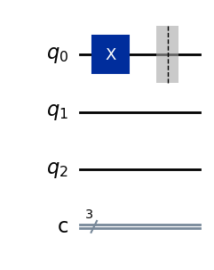

```python
from qiskit.circuit import QuantumCircuit
from qiskit.circuit.library import Barrier

b=Barrier(1)
qc= QuantumCircuit(3,3)
qc.compose(xgate).compose(b).draw('mpl')
```

### Standard Operations

- Measure --> Measurement in the computational basis
- Reset --> Reset a Qubit to |0>

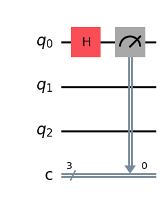

```python
from qiskit.circuit.library import Measure
measure =Measure()
qc.compose(hgate).compose(measure).draw('mpl')
```

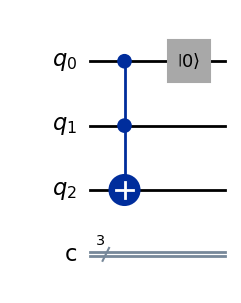

```python
from qiskit.circuit.library import Reset
reset =Reset()
qc.compose(ccxgate).compose(reset).draw('mpl')
```

### Generalized Gates

- Extends the standard gates
- contains variadic gates "number of qubits depends on the input"
- It is recommended to use Gates that derive `Instrcution` or `Gate` instead of `QuantumCircuit` , as the former allows the compiler to reason about it on an abstract level , while the latter is eagerly constructed

```python
from qiskit.circuit.library import DiagonalGate

diagonal = DiagonalGate([1, 1j])
print(diagonal.num_qubits)

diagonal = DiagonalGate([1, 1, 1, -1])
print(diagonal.num_qubits)
```

```
1
2
```

The following gates derive `Gate` or `Insturction`

- DiagonalGate --> A generic diagonal quantum gate.
- PermutationGate --> A gate that permutes qubits.
- MCMTGate --> The multi-controlled multi-target gate, for an arbitrary singly controlled target gate.
- MCPhaseGate --> Multi-controlled-Phase gate.
- MCXGate --> The general, multi-controlled X gate.
- MSGate --> The Mølmer–Sørensen gate.
- RVGate --> Rotation around arbitrary rotation axis v where ∥v∥2 is angle of rotation in radians.
- PauliGate --> A multi-qubit Pauli gate.
- LinearFunction --> A linear reversible circuit on n qubits.
- Isometry --> Decomposition of arbitrary isometries from mm to nn qubits.
- UnitaryGate --> Class quantum gates specified by a unitary matrix.
- UCGate --> Uniformly controlled gate (also called multiplexed gate).
- UCPauliRotGate --> Uniformly controlled Pauli rotations.
- UCRXGate --> Uniformly controlled Pauli-X rotations.
- UCRYGate --> Uniformly controlled Pauli-Y rotations.
- UCRZGate --> Uniformly controlled Pauli-Z rotations.

The following gates derive `QuantumCircuit`

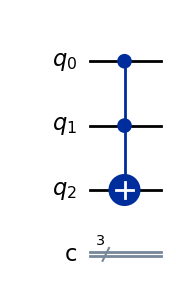

```python
from qiskit.circuit.library import MCXGate

mcxgate = MCXGate(num_ctrl_qubits=2)
qc.compose(mcxgate).draw('mpl')
```

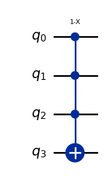

```python
from qiskit.circuit.library import MCMTGate

mcmtGate = MCMTGate(gate=xgate,num_ctrl_qubits=3,num_target_qubits=1)
qc= QuantumCircuit(4,0)
qc.compose(mcmtGate).draw('mpl')
```

### Boolean Logic Gates

The following gates derive `Gate`

- AndGate --> A gate representing the logical AND operation on a number of qubits.
- OrGate --> A gate representing the logical OR operation on a number of qubits.
- BitwiseXorGate --> An n-qubit gate for bitwise xor-ing the input with some integer amount.
- InnerProductGate --> A 2n-qubit Boolean function that computes the inner product of two n-qubit vectors over F2.

The following gates derive `QuantumCircuit`

- AND --> A circuit implementing the logical AND operation on a number of qubits.
- OR --> A circuit implementing the logical OR operation on a number of qubits.
- XOR --> An n_qubit circuit for bitwise xor-ing the input with some integer amount.
- InnerProduct --> A 2n-qubit Boolean function that computes the inner product of two n-qubit vectors over F2F2.

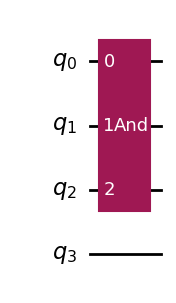

```python
from qiskit.circuit.library import AndGate

andgate = AndGate(num_variable_qubits=2)

qc.compose(andgate).draw('mpl')
```